# MTH6139 Time Series

Coursework 1

School of Mathematical Sciences Nishath Khatoon (210277490)

March 2024

### 1.1 Project- FISH POPULATION TIME SERIES

This time series represents the number of new fish for a period ranging from 1950 to 1987. The data collected is used to monitor the population of different fish species within an area. Rec refers to ‘recruitment’, which suggests the population of the number of young fish that grow up enough to have a good chance of living as long as adult fish. Recruitment data is vital to tell us if the fish population is healthy and whether the increasing population of young fish becoming adult fish shows that the fish population is thriving. It helps us learn more about environmental changes, i.e., pollution that may lead to habitat loss. This will directly affect the population of fish in the sea. We can observe and predict how fish populations might change over time by looking at recruitment trends. Observing these trends will be useful for finding solutions to help protect the fish population.

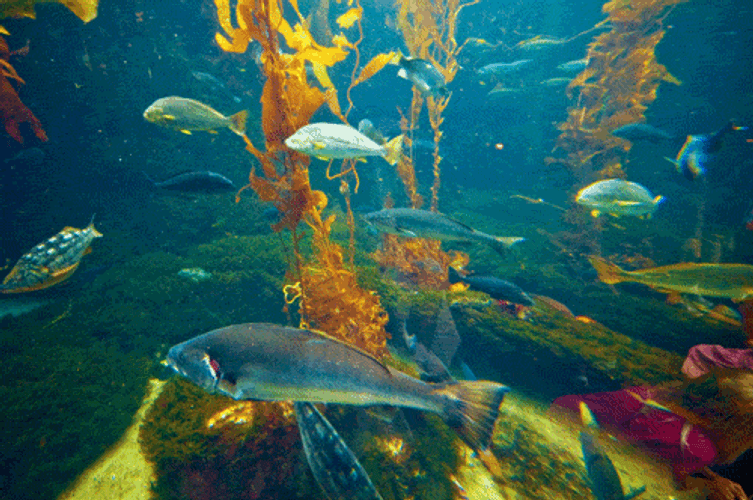

### 1.2 Time Series Analysis

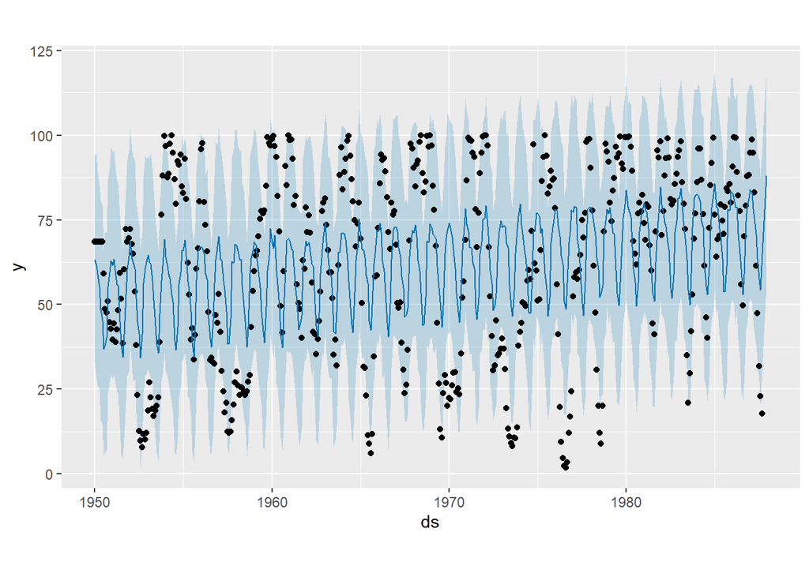

The time series plot illustrates data points represented by black dots. The black dots are scattered, which suggests there is variability. Over time, we have seen a slight increase in the spread of the data points. The blue line outlines the trend/pattern of this time series period over 37 years. The trend suggests a seasonal pattern where we can see consistent fluctuations and a slight increase in recruitment throughout the years. Finally, we can see blue shading around the trend line, indicating uncertainty in estimating the trend. Since the shaded area is wide, this shows larger uncertainty.

### 1.3 Decomposition of additive time series

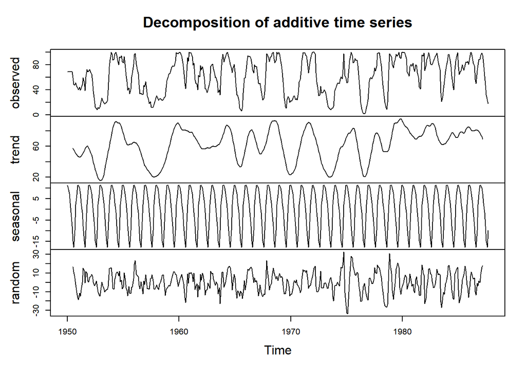

### 1.4 Prophet seasonality (weekly, daily, yearly)

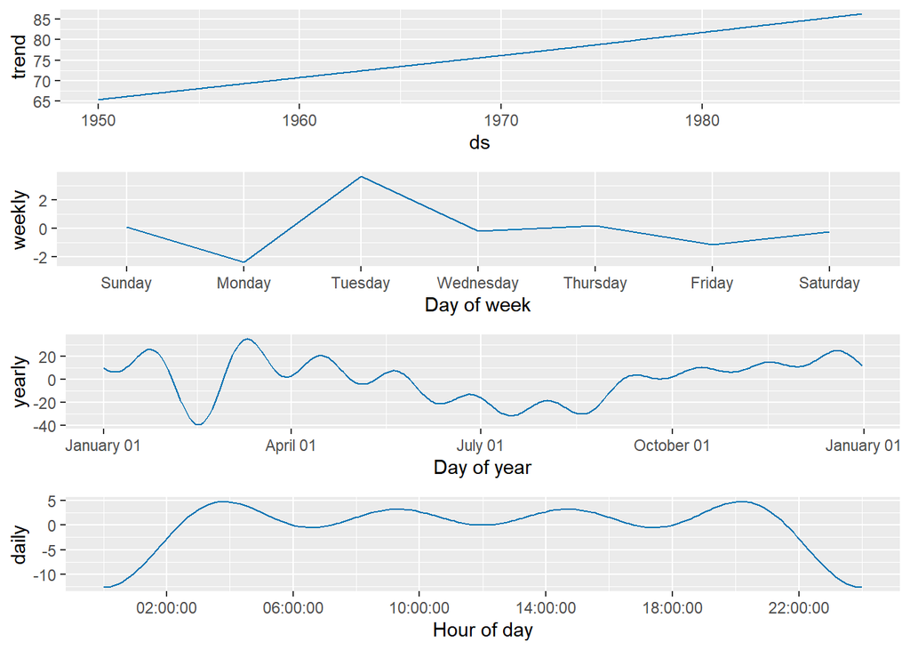

Over the years, more young fish have survived and joined the fish population. This increase could be due to various positive changes such as better protection of the fish environment, cleaner water, fewer fish being caught before they can reproduce, or overall conditions underwater that help young fish thrive. However, we can not predict the trend will continue to increase because this depends on the circumstances and external environmental factors that may affect the fish population. The weekly component shows a sharp peak on Tuesdays. If fish are being counted every week, we might notice more young fish at certain times. For example, if fishing is not allowed on certain days, or if predators like birds or bigger fish have weekly patterns that affect the baby fish, we might see weekly changes. Fish often have specific times of the year when they have their babies, known as the spawning season. We may see more young fish at certain times of the year and fewer at other times. The weather, food availability, and fish migration to different places can influence these patterns.

```
##
## Call:
## lm(formula = y ~ ds, data = rec.df)
##
## Residuals:
##     Min      1Q  Median      3Q     Max
## -64.864 -22.696   5.365  23.036  45.855
##
## Coefficients:
##               Estimate Std. Error t value Pr(>|t|)
## (Intercept) -1035.5774   232.0641  -4.462 1.02e-05 ***
## ds              0.5576     0.1179   4.731 3.00e-06 ***
## ---
## Signif. codes:  0 '***' 0.001 '**' 0.01 '*' 0.05 '.' 0.1 ' ' 1
##
## Residual standard error: 27.34 on 451 degrees of freedom
## Multiple R-squared:  0.04728,    Adjusted R-squared:  0.04517
## F-statistic: 22.38 on 1 and 451 DF,  p-value: 2.996e-06
```

### 1.5 Dyplot of the forecast

[interactive chart not shown]

The dyplot is a good visualisation of the forecast and displays the actual and predicted data over the years.

### 1.6 References

https://edis.ifas.ufl.edu/publication/FA222

https://www.nature.com/articles/s41598-020-73025-z